# RNA-seq analysis

Yang

01/08/2019

## Setup

```r
library(limma)
library(edgeR)
library(AnnotationHub)
library(tidyverse)
library(magrittr)
library(pander)
library(RColorBrewer)
library(ggrepel)
library(swfdr)
library(qvalue)
library(scales)
library(here)
theme_set(theme_bw())
panderOptions("big.mark", ",")
panderOptions("table.split.table", Inf)
panderOptions("table.style", "rmarkdown")
if (interactive()) setwd(file.path(here(), "R"))
```

Annotation was set up as a EnsDb object based on Ensembl Release 96

```r
ah <- AnnotationHub() %>%
  subset(species == "Danio rerio") %>%
  subset(dataprovider == "Ensembl") %>%
  subset(rdataclass == "EnsDb")
ensDb <- AnnotationHub()[["AH69169"]]
genes <- genes(ensDb)
```

Prior to count-level analysis, the initial dataset was pre-processed using the following steps:

- Adapters were removed from any reads
- Bases were removed from the end of reads when the quality score dipped below 30
- Reads < 35bp after trimming were discarded

After trimming alignment was performed using STAR v2.5.3a to the *Danio rerio* genome included in Ensembl Release 96 (GRCz11). Aligned reads were counted for each gene if the following criteria were satisfied:

- Alignments were unique
- Alignments strictly overlapped exonic regions

```r
minSamples <- 6
minCpm <- 1
```

```r
counts <- file.path("../2_alignedData/featureCounts/genes.out") %>%
    read_tsv() %>%
    set_colnames(basename(colnames(.))) %>%
    set_colnames(str_remove(colnames(.), "Aligned.+")) %>%
  gather(key = "Library", value = "Counts", -Geneid) %>%
  mutate(Sample = str_remove_all(Library, "_2")) %>%
  group_by(Geneid, Sample) %>%
  summarise(Counts = sum(Counts)) %>%
  spread(key = "Sample", value = "Counts") %>%
  as.data.frame() %>%
  column_to_rownames("Geneid")
genes2keep <- cpm(counts) %>%
  is_greater_than(minCpm) %>%
  rowSums() %>%
  is_weakly_greater_than(minSamples)
```

Counts were then loaded and summed across replicate sequencing runs. Genes were only retained if receiving more than 1 cpm in at least 6 samples. This filtering step discarded 12,661 genes as undetectable and retained 19,396 genes for further analysis.

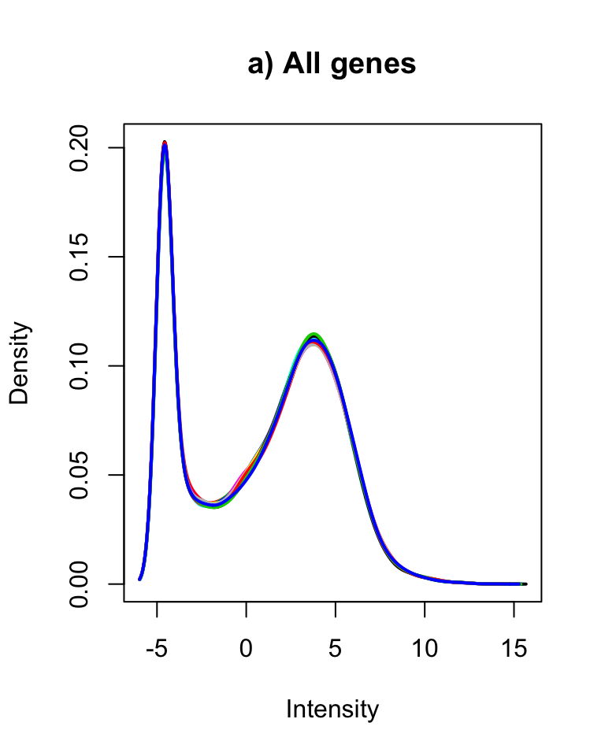

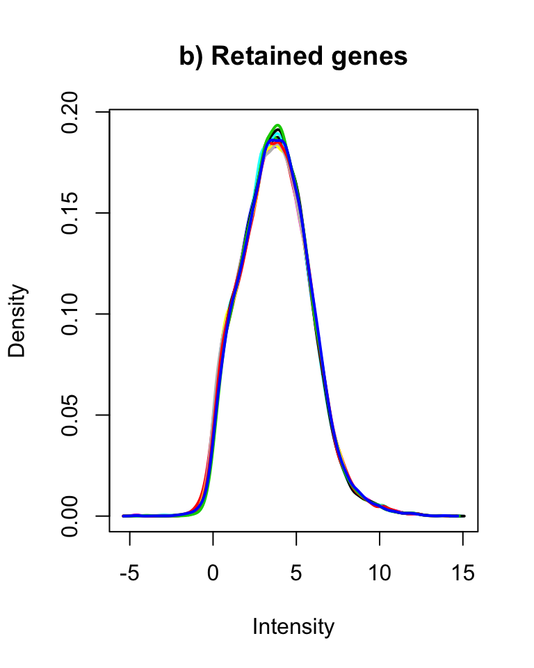

Distribution of logCPM values for a) all and b) retained genes

```r
plotDensities(cpm(counts, log = TRUE), legend = FALSE, main = "a) All genes")
plotDensities(cpm(counts[genes2keep,], log = TRUE), legend = FALSE, main = "b) Retained genes")
```

```r
dgeList <- counts %>%
  .[genes2keep,] %>%
  DGEList(
    samples = tibble(
      sample = colnames(.),
      group = str_replace_all(sample, "[0-9]*[A-Z]([12])Lardelli", "\\1")
    ) %>%
      as.data.frame(),
        genes = genes[rownames(.)] %>%
            as.data.frame() %>%
            dplyr::select(
                ensembl_gene_id = gene_id,
                chromosome_name = seqnames,
                description,
                external_gene_name = gene_name
            )
    ) %>%
    calcNormFactors(method = "TMM") %>%
    estimateDisp()
```

```
## Design matrix not provided. Switch to the classic mode.
```

```r
dgeList$samples$Genotype <- c("Q96K97del/+", "WT")[dgeList$samples$group] %>%
  factor(levels = c("WT", "Q96K97del/+"))
```

Counts were then formed into a DGEList object. Library sizes after alignment, counting and gene filtering ranged between *44,498,373* and *52,779,608* reads.

## Data Inspection

```r
v <- dgeList %>%
    voomWithQualityWeights(design = matrix(1, nrow = ncol(.)))
```

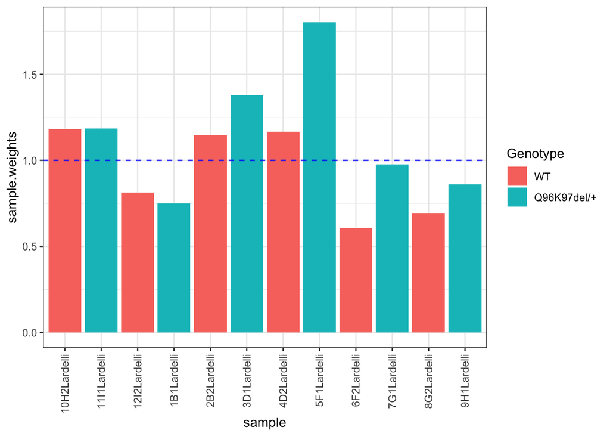

Sample weights with the ideal equal weight of 1 shown as a horizontal line.

```r
pca <- v$E %>%
    t() %>%
    prcomp()
summary(pca)$importance %>% pander(split.tables = Inf)
```

|  | PC1 | PC2 | PC3 | PC4 | PC5 | PC6 | PC7 | PC8 | PC9 | PC10 | PC11 | PC12 |
| --- | --- | --- | --- | --- | --- | --- | --- | --- | --- | --- | --- | --- |
| **Standard deviation** | 21.98 | 17.89 | 14.06 | 12.92 | 11.64 | 11.14 | 10.79 | 10.61 | 9.846 | 7.989 | 7.633 | 5.872e-14 |
| **Proportion of Variance** | 0.2576 | 0.1706 | 0.1055 | 0.08908 | 0.07222 | 0.06621 | 0.06209 | 0.05998 | 0.05169 | 0.03403 | 0.03107 | 0 |
| **Cumulative Proportion** | 0.2576 | 0.4282 | 0.5336 | 0.6227 | 0.6949 | 0.7611 | 0.8232 | 0.8832 | 0.9349 | 0.9689 | 1 | 1 |

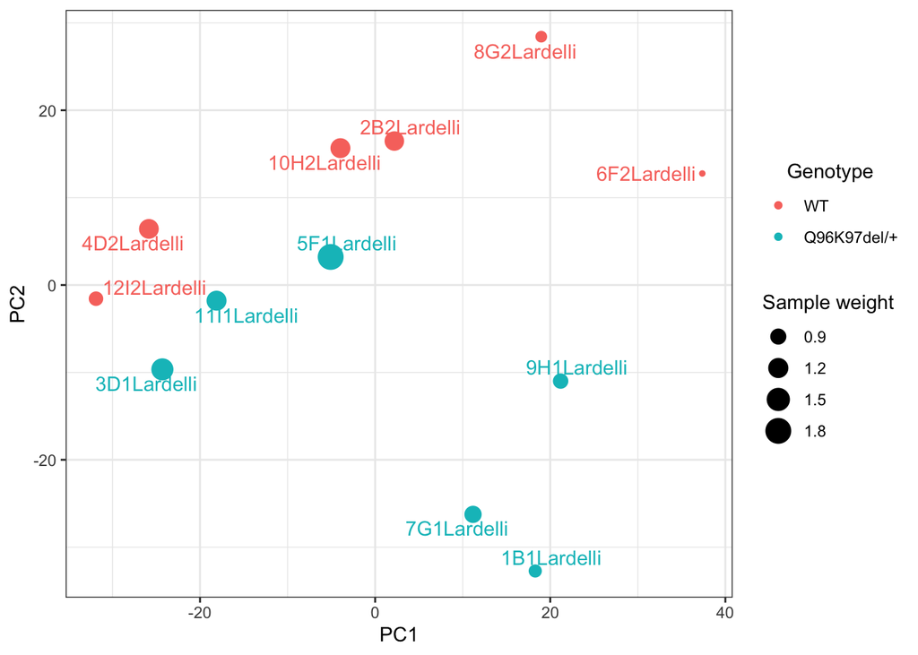

psen1 expression checking

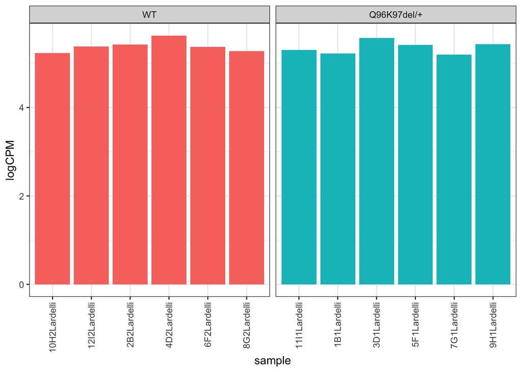

Expression of *psen1* across all samples.

rpl13 expression checking (house-keeping gene)

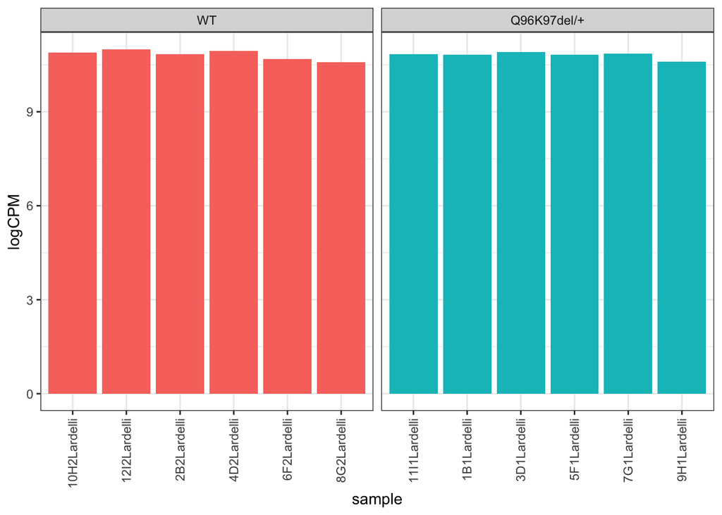

Expression of *rpl13* across all samples.

## Analysis

### DGE Analysis

```r
design <- model.matrix(~Genotype, data = v$targets)
colnames(design) <- c("Wildtype", "MutvsWildtype")
efit <- v %>%
    lmFit(design) %>%
    eBayes()
```

```r
deGenes <- efit %>%
    topTable(coef = "MutvsWildtype", number = Inf, sort.by = "p") %>%
    as_tibble() %>%
  mutate(
    q = qvalue(P.Value)$qvalues,
    Sig = q < 0.1 & abs(logFC) > 0.9
  )
```

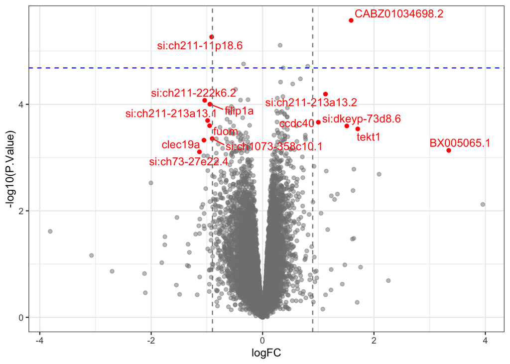

Volcano plot highlighting DE genes. Genes were considered as DE if receiving a q-value < 0.05 and with logFC beyond the range $\pm 0.9$. Genes indicated in red below the blue line recieved a q-value < 0.1 and are of potential interest.

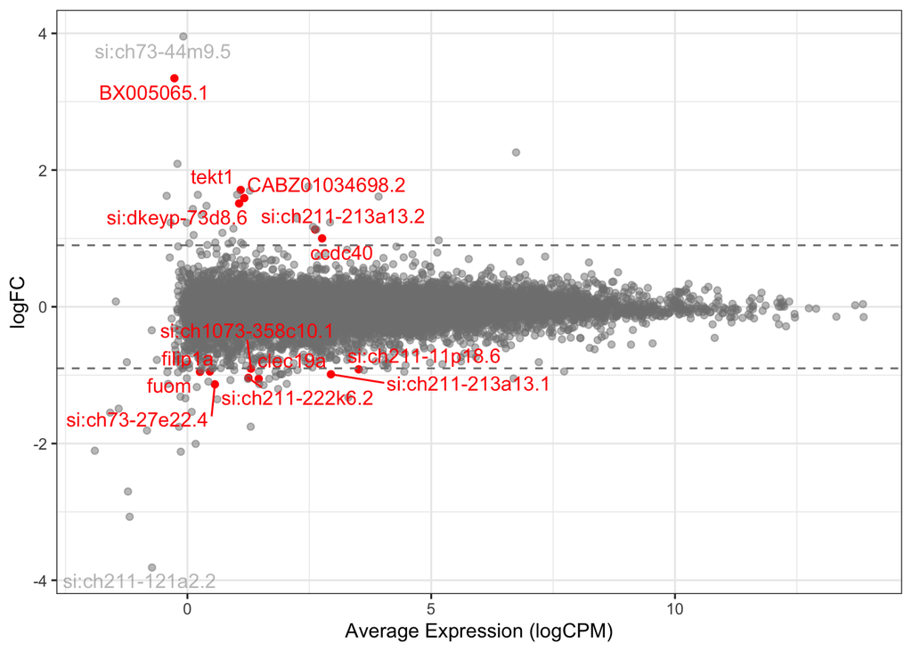

logFC plotted against expression level with significant DE genes shown in red.

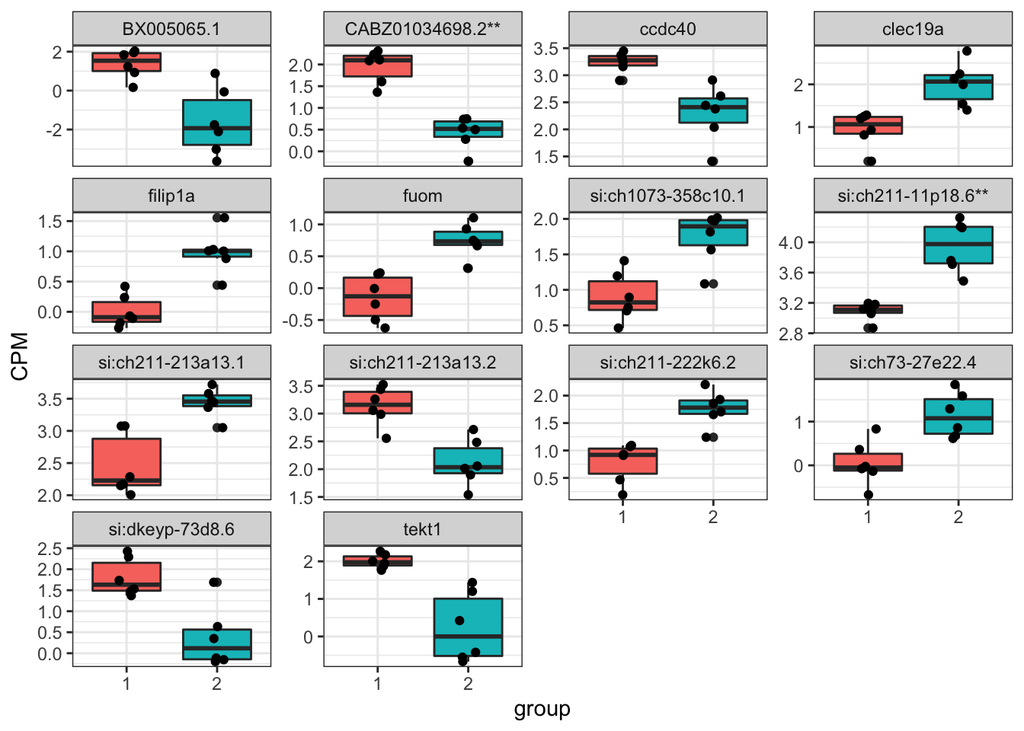

Top 20 results from DGE analysis. FDR indicates the Benjamini-Hochberg FDR, whilst q-values represent the Storey FDR.

| ensembl_gene_id | description | external_gene_name | logFC | AveExpr | t | P.Value | FDR | q |
| --- | --- | --- | --- | --- | --- | --- | --- | --- |
| ENSDARG00000099511 | NUL | CABZ01034698.2 | 1.59 | 1.167 | 7.874 | 2.651e-06 | 0.05032 | 0.03698 |
| ENSDARG00000077068 | si:ch211-11p18.6 | si:ch211-11p18.6 | -0.9145 | 3.513 | -7.367 | 5.433e-06 | 0.05032 | 0.03698 |
| ENSDARG00000076805 | leukocyte receptor cluster (LRC) member 8 | leng8 | 0.3152 | 8.013 | 7.121 | 7.783e-06 | 0.05032 | 0.03698 |
| ENSDARG00000076439 | protein phosphatase 4, catalytic subunit b | ppp4cb | -0.3421 | 3.99 | -6.588 | 1.743e-05 | 0.06697 | 0.04922 |
| ENSDARG00000070140 | zgc:154169 | RETSAT | 0.8113 | 0.2597 | 6.524 | 1.925e-05 | 0.06697 | 0.04922 |
| ENSDARG00000063195 | PX domain containing serine/threonine kinase | pxk | 0.3697 | 6.012 | 6.477 | 2.072e-05 | 0.06697 | 0.04922 |
| ENSDARG00000037613 | galectin 8b | lgals8b | 0.6791 | 1.213 | 6.179 | 3.32e-05 | 0.08915 | 0.06552 |
| ENSDARG00000041533 | coiled-coil domain containing 130 | ccdc130 | 0.323 | 3.453 | 6.093 | 3.816e-05 | 0.08915 | 0.06552 |
| ENSDARG00000019995 | bone morphogenetic protein 4 | bmp4 | 0.5405 | 3.405 | 6.043 | 4.137e-05 | 0.08915 | 0.06552 |
| ENSDARG00000042876 | ABRA C-terminal like | abracl | -0.4845 | 2.961 | -5.9 | 5.228e-05 | 0.1014 | 0.07452 |
| ENSDARG00000093024 | si:ch211-213a13.2 | si:ch211-213a13.2 | 1.13 | 2.619 | 5.775 | 6.422e-05 | 0.102 | 0.07497 |
| ENSDARG00000051879 | ATP-binding cassette, sub-family C (CFTR/MRP), member 8 | abcc8 | 0.3654 | 5.091 | 5.711 | 7.142e-05 | 0.102 | 0.07497 |
| ENSDARG00000022832 | BCL2 interacting protein 4 | bnip4 | 0.2641 | 5.525 | 5.67 | 7.651e-05 | 0.102 | 0.07497 |
| ENSDARG00000076870 | piezo-type mechanosensitive ion channel component 1 | piezo1 | -0.2617 | 4.533 | -5.63 | 8.179e-05 | 0.102 | 0.07497 |
| ENSDARG00000103824 | histidine triad nucleotide binding protein 1 | hint1 | -0.3962 | 3.271 | -5.621 | 8.314e-05 | 0.102 | 0.07497 |
| ENSDARG00000087046 | si:ch211-222k6.2 | si:ch211-222k6.2 | -1.039 | 1.251 | -5.614 | 8.415e-05 | 0.102 | 0.07497 |
| ENSDARG00000078419 | filamin A interacting protein 1a | filip1a | -0.9465 | 0.4612 | -5.515 | 9.937e-05 | 0.1072 | 0.07875 |
| ENSDARG00000062618 | potassium inwardly-rectifying channel, subfamily J, member 12b | kcnj12b | -0.5601 | 3.366 | -5.458 | 0.0001095 | 0.1072 | 0.07875 |
| ENSDARG00000031915 | hypoxia inducible factor 1 subunit alpha inhibitor | hif1an | 0.446 | 4.079 | 5.423 | 0.0001163 | 0.1072 | 0.07875 |
| ENSDARG00000044253 | progestin and adipoQ receptor family member IIIb | paqr3b | -0.5263 | 2.012 | -5.386 | 0.0001238 | 0.1072 | 0.07875 |

The final results were exported as the file `Q96K97delhetvsWildtype.csv`

```r
write_csv(deGenes, "../results/Q96K97delhetvsWildtype.csv")
```

## Enrichment Analysis

An existing mapping of zebrafish Ensembl identifiers to human Entrez identifiers was obtained

```r
ens2Entrez <- file.path("../R/mart_export.tsv") %>%
    read_tsv()
goSummaries <- url("https://uofabioinformaticshub.github.io/summaries2GO/data/goSummaries.RDS") %>%
  readRDS()
```

```r
de <- deGenes %>%
    dplyr::filter(q < 0.1 & abs(logFC) > 0.9) %>%
    dplyr::select(`Gene stable ID` = ensembl_gene_id) %>%
    left_join(ens2Entrez) %>%
    dplyr::filter(!is.na(`NCBI gene ID`)) %>%
    .[["NCBI gene ID"]] %>%
    unique()
uv <- deGenes %>%
    dplyr::select(`Gene stable ID` = ensembl_gene_id) %>%
    left_join(ens2Entrez) %>%
    dplyr::filter(!is.na(`NCBI gene ID`)) %>%
    .[["NCBI gene ID"]] %>%
    unique()
```

```r
goResults <- goana(de = de, universe = uv, species = "Hs")
head(goResults)
```

```
##                                       Term Ont     N DE       P.DE
## GO:0006805    xenobiotic metabolic process  BP    92  0 1.00000000
## GO:0008150              biological_process  BP 11681 22 0.67448578
## GO:0008152               metabolic process  BP  8061 21 0.01233047
## GO:0009410 response to xenobiotic stimulus  BP   225  0 1.00000000
## GO:0009987                cellular process  BP 10569 22 0.23492831
## GO:0042221            response to chemical  BP  3046  1 0.99858714
```

```r
goResults %>%
    rownames_to_column("id") %>%
    left_join(goSummaries) %>%
    as_tibble() %>%
    dplyr::filter(shortest_path> 3, DE > 1) %>%
    arrange(P.DE) %>%
    mutate(adjP = p.adjust(P.DE, "bonferroni")) %>%
    dplyr::filter(adjP < 0.05) %>%
    pander(caption = "GO Terms potentially enriched in the set of differentially expressed genes")
```

GO Terms potentially enriched in the set of differentially expressed genes

| id | Term | Ont | N | DE | P.DE | shortest_path | longest_path | terminal_node | ontology | adjP |
| --- | --- | --- | --- | --- | --- | --- | --- | --- | --- | --- |
| GO:0003677 | DNA binding | MF | 1,431 | 20 | 1.373e-15 | 4 | 4 | FALSE | MF | 5.63e-14 |
| GO:0006355 | regulation of transcription, DNA-templated | BP | 2,253 | 20 | 8.975e-12 | 5 | 10 | FALSE | BP | 3.68e-10 |
| GO:1903506 | regulation of nucleic acid-templated transcription | BP | 2,306 | 20 | 1.399e-11 | 6 | 9 | FALSE | BP | 5.738e-10 |
| GO:2001141 | regulation of RNA biosynthetic process | BP | 2,312 | 20 | 1.471e-11 | 5 | 8 | FALSE | BP | 6.029e-10 |
| GO:0006351 | transcription, DNA-templated | BP | 2,404 | 20 | 3.094e-11 | 5 | 9 | FALSE | BP | 1.268e-09 |
| GO:0097659 | nucleic acid-templated transcription | BP | 2,445 | 20 | 4.267e-11 | 6 | 8 | FALSE | BP | 1.75e-09 |
| GO:0032774 | RNA biosynthetic process | BP | 2,456 | 20 | 4.648e-11 | 5 | 7 | FALSE | BP | 1.905e-09 |
| GO:0051252 | regulation of RNA metabolic process | BP | 2,471 | 20 | 5.218e-11 | 4 | 7 | FALSE | BP | 2.139e-09 |
| GO:2000112 | regulation of cellular macromolecule biosynthetic process | BP | 2,560 | 20 | 1.021e-10 | 5 | 6 | FALSE | BP | 4.186e-09 |
| GO:0010556 | regulation of macromolecule biosynthetic process | BP | 2,659 | 20 | 2.093e-10 | 4 | 5 | FALSE | BP | 8.58e-09 |
| GO:0006357 | regulation of transcription by RNA polymerase II | BP | 1,677 | 17 | 2.128e-10 | 6 | 11 | FALSE | BP | 8.726e-09 |
| GO:0019219 | regulation of nucleobase-containing compound metabolic process | BP | 2,696 | 20 | 2.716e-10 | 4 | 5 | FALSE | BP | 1.114e-08 |
| GO:0031326 | regulation of cellular biosynthetic process | BP | 2,794 | 20 | 5.323e-10 | 4 | 5 | FALSE | BP | 2.182e-08 |
| GO:0006366 | transcription by RNA polymerase II | BP | 1,815 | 17 | 7.508e-10 | 6 | 10 | FALSE | BP | 3.078e-08 |
| GO:0046872 | metal ion binding | MF | 2,883 | 20 | 9.592e-10 | 4 | 4 | FALSE | MF | 3.933e-08 |
| GO:0034654 | nucleobase-containing compound biosynthetic process | BP | 2,884 | 20 | 9.655e-10 | 4 | 5 | FALSE | BP | 3.959e-08 |
| GO:0018130 | heterocycle biosynthetic process | BP | 2,937 | 20 | 1.358e-09 | 4 | 4 | FALSE | BP | 5.569e-08 |
| GO:0019438 | aromatic compound biosynthetic process | BP | 2,948 | 20 | 1.457e-09 | 4 | 4 | FALSE | BP | 5.972e-08 |
| GO:0010468 | regulation of gene expression | BP | 2,981 | 20 | 1.794e-09 | 4 | 5 | FALSE | BP | 7.355e-08 |
| GO:1901362 | organic cyclic compound biosynthetic process | BP | 3,057 | 20 | 2.871e-09 | 4 | 4 | FALSE | BP | 1.177e-07 |
| GO:0016070 | RNA metabolic process | BP | 3,128 | 20 | 4.403e-09 | 5 | 6 | FALSE | BP | 1.805e-07 |
| GO:0034645 | cellular macromolecule biosynthetic process | BP | 3,312 | 20 | 1.272e-08 | 4 | 5 | FALSE | BP | 5.213e-07 |
| GO:0044271 | cellular nitrogen compound biosynthetic process | BP | 3,425 | 20 | 2.362e-08 | 4 | 4 | FALSE | BP | 9.684e-07 |
| GO:0009059 | macromolecule biosynthetic process | BP | 3,428 | 20 | 2.4e-08 | 4 | 4 | FALSE | BP | 9.841e-07 |
| GO:0090304 | nucleic acid metabolic process | BP | 3,475 | 20 | 3.084e-08 | 4 | 5 | FALSE | BP | 1.264e-06 |
| GO:0010467 | gene expression | BP | 3,695 | 20 | 9.494e-08 | 4 | 4 | FALSE | BP | 3.893e-06 |
| GO:0005634 | nucleus | CC | 4,922 | 20 | 1.571e-05 | 4 | 7 | FALSE | CC | 0.000644 |

**R version 3.6.0 (2019-04-26)**

**Platform:** x86_64-apple-darwin15.6.0 (64-bit)

**locale:** en_AU.UTF-8||en_AU.UTF-8||en_AU.UTF-8||C||en_AU.UTF-8||en_AU.UTF-8

**attached base packages:** *stats4*, *parallel*, *stats*, *graphics*, *grDevices*, *utils*, *datasets*, *methods* and *base*

**other attached packages:** *GenomicRanges(v.1.36.0)*, *GenomeInfoDb(v.1.20.0)*, *IRanges(v.2.18.1)*, *S4Vectors(v.0.22.0)*, *here(v.0.1)*, *scales(v.1.0.0)*, *qvalue(v.2.16.0)*, *swfdr(v.1.10.0)*, *ggrepel(v.0.8.1)*, *RColorBrewer(v.1.1-2)*, *pander(v.0.6.3)*, *magrittr(v.1.5)*, *forcats(v.0.4.0)*, *stringr(v.1.4.0)*, *dplyr(v.0.8.3)*, *purrr(v.0.3.2)*, *readr(v.1.3.1)*, *tidyr(v.0.8.3)*, *tibble(v.2.1.3)*, *ggplot2(v.3.2.0)*, *tidyverse(v.1.2.1)*, *AnnotationHub(v.2.16.0)*, *BiocFileCache(v.1.8.0)*, *dbplyr(v.1.4.2)*, *BiocGenerics(v.0.30.0)*, *edgeR(v.3.26.6)* and *limma(v.3.40.6)*

**loaded via a namespace (and not attached):** *nlme(v.3.1-141)*, *bitops(v.1.0-6)*, *lubridate(v.1.7.4)*, *bit64(v.0.9-7)*, *httr(v.1.4.1)*, *rprojroot(v.1.3-2)*, *tools(v.3.6.0)*, *backports(v.1.1.4)*, *R6(v.2.4.0)*, *DBI(v.1.0.0)*, *lazyeval(v.0.2.2)*, *colorspace(v.1.4-1)*, *withr(v.2.1.2)*, *tidyselect(v.0.2.5)*, *bit(v.1.1-14)*, *curl(v.4.0)*, *compiler(v.3.6.0)*, *cli(v.1.1.0)*, *rvest(v.0.3.4)*, *Biobase(v.2.44.0)*, *xml2(v.1.2.1)*, *labeling(v.0.3)*, *rappdirs(v.0.3.1)*, *digest(v.0.6.20)*, *rmarkdown(v.1.14)*, *XVector(v.0.24.0)*, *pkgconfig(v.2.0.2)*, *htmltools(v.0.3.6)*, *highr(v.0.8)*, *rlang(v.0.4.0)*, *readxl(v.1.3.1)*, *rstudioapi(v.0.10)*, *RSQLite(v.2.1.2)*, *shiny(v.1.3.2)*, *generics(v.0.0.2)*, *jsonlite(v.1.6)*, *RCurl(v.1.95-4.12)*, *GO.db(v.3.8.2)*, *GenomeInfoDbData(v.1.2.1)*, *Rcpp(v.1.0.2)*, *munsell(v.0.5.0)*, *stringi(v.1.4.3)*, *yaml(v.2.2.0)*, *zlibbioc(v.1.30.0)*, *org.Hs.eg.db(v.3.8.2)*, *plyr(v.1.8.4)*, *grid(v.3.6.0)*, *blob(v.1.2.0)*, *promises(v.1.0.1)*, *crayon(v.1.3.4)*, *lattice(v.0.20-38)*, *haven(v.2.1.1)*, *splines(v.3.6.0)*, *hms(v.0.5.0)*, *locfit(v.1.5-9.1)*, *zeallot(v.0.1.0)*, *knitr(v.1.24)*, *pillar(v.1.4.2)*, *reshape2(v.1.4.3)*, *glue(v.1.3.1)*, *evaluate(v.0.14)*, *BiocManager(v.1.30.4)*, *modelr(v.0.1.5)*, *vctrs(v.0.2.0)*, *httpuv(v.1.5.1)*, *cellranger(v.1.1.0)*, *gtable(v.0.3.0)*, *assertthat(v.0.2.1)*, *xfun(v.0.8)*, *mime(v.0.7)*, *xtable(v.1.8-4)*, *broom(v.0.5.2)*, *later(v.0.8.0)*, *AnnotationDbi(v.1.46.0)*, *memoise(v.1.1.0)* and *interactiveDisplayBase(v.1.22.0)*